# demo_network_IDS

## Load network data

Read in network traffic data from KDD’99. The downloaded training and test set data are a reduced version of the original release. The reduced version consists of 10% of the original data size and has been corrected for errors.

```r
rm(list=ls())
data_trn <- read.table("kddcup.data_10_percent_corrected", sep = ",")
data_tst <- read.table("corrected", sep = ",")
data_trn[1,] #show an instance
```

```
##   V1  V2   V3 V4  V5   V6 V7 V8 V9 V10 V11 V12 V13 V14 V15 V16 V17 V18 V19
## 1  0 tcp http SF 181 5450  0  0  0   0   0   1   0   0   0   0   0   0   0
##   V20 V21 V22 V23 V24 V25 V26 V27 V28 V29 V30 V31 V32 V33 V34 V35  V36 V37
## 1   0   0   0   8   8   0   0   0   0   1   0   0   9   9   1   0 0.11   0
##   V38 V39 V40 V41     V42
## 1   0   0   0   0 normal.
```

## Rename features

Assign column (attribute) names according to dataset description.

```r
#rename features/columns
feature_names <- c("duration","protocol_type","service","flag","src_bytes","dst_bytes",
                   "land","wrong_fragment","urgent","hot","num_failed_logins","logged_in",
                   "num_compromised","root_shell","su_attempted","num_root",
                   "num_file_creations","num_shells","num_access_files",
                   "num_outbound_cmds","is_host_login","is_guest_login","count",
                   "srv_count","serror_rate", "srv_serror_rate","rerror_rate",
                   "srv_rerror_rate","same_srv_rate","diff_srv_rate","srv_diff_host_rate",
                   "dst_host_count","dst_host_srv_count","dst_host_same_srv_rate",
                   "dst_host_diff_srv_rate","dst_host_same_src_port_rate",
                   "dst_host_srv_diff_host_rate","dst_host_serror_rate",
                   "dst_host_srv_serror_rate","dst_host_rerror_rate",
                   "dst_host_srv_rerror_rate","attack")
colnames(data_trn) <- feature_names
colnames(data_tst) <- feature_names
```

## Extract and show labels

Extract labels from the attribute `attack` for the training set and test set, and print the labels with their frequency of occurrence.

```r
#extract unique labels
ltrn <- unique(data_trn[,"attack"]) #training labels
ltst <- unique(data_tst[,"attack"]) #test labels
#print(ltrn)
#print(ltst)
```

### Training set labels

```r
#print frequency table for labels
df <- as.data.frame(table(data_trn[,"attack"]))
colnames(df) <- c("label","frequency")
print(df,row.names = TRUE)
```

```
##               label frequency
## 1             back.      2203
## 2  buffer_overflow.        30
## 3        ftp_write.         8
## 4     guess_passwd.        53
## 5             imap.        12
## 6          ipsweep.      1247
## 7             land.        21
## 8       loadmodule.         9
## 9         multihop.         7
## 10         neptune.    107201
## 11            nmap.       231
## 12          normal.     97278
## 13            perl.         3
## 14             phf.         4
## 15             pod.       264
## 16       portsweep.      1040
## 17         rootkit.        10
## 18           satan.      1589
## 19           smurf.    280790
## 20             spy.         2
## 21        teardrop.       979
## 22     warezclient.      1020
## 23     warezmaster.        20
```

### Test set labels

```r
df <- as.data.frame(table(data_tst[,"attack"]))
colnames(df) <- c("label","frequency")
print(df,row.names = TRUE)
```

```
##               label frequency
## 1          apache2.       794
## 2             back.      1098
## 3  buffer_overflow.        22
## 4        ftp_write.         3
## 5     guess_passwd.      4367
## 6       httptunnel.       158
## 7             imap.         1
## 8          ipsweep.       306
## 9             land.         9
## 10      loadmodule.         2
## 11        mailbomb.      5000
## 12           mscan.      1053
## 13        multihop.        18
## 14           named.        17
```

[output cut: 24 more lines]

## Add a binary label (attack/normal)

For each instance, add a binary label, `Lb`,specifying whether the object represents normal network traffic or an attack (anomaly). An anomaly can be any one of the attack labels that are different than ‘*normal*’. An anomaly is represented by the label ‘1’, and a normal instance by the label ‘0’.

```r
#add binary label for normal (0) or anomaly
Lb <- as.numeric(data_trn$attack != "normal.")
data_trn$Lb <- Lb
print(as.data.frame(table(Lb)), row.names = FALSE)
```

```
##  Lb   Freq
##   0  97278
##   1 396743
```

```r
Lb <- as.numeric(data_tst$attack != "normal.")
data_tst$Lb <- Lb
print(as.data.frame(table(Lb)), row.names = FALSE)
```

```
##  Lb   Freq
##   0  60593
##   1 250436
```

## Count duplicate observations

Each of the training/test set contains lots of duplicate observations. By removing these, we obtain a considerable reduction is dataset size.

### Duplicate observations in training set

```r
#count duplicate rows/observations
d <- duplicated(data_trn)
#length(d) #number of obs.
#sum(d) #number of duplicates
distinct_trn <- length(d) - sum(d)

d_attack <- duplicated(data_trn[data_trn$Lb==1,])
#length(d_attack)
#sum(d_attack)
distinct_trn_attack <- length(d_attack) - sum(d_attack)

d_normal <- duplicated(data_trn[data_trn$Lb==0,])
#length(d_normal)
#sum(d_normal)
distinct_trn_normal <- length(d_normal) - sum(d_normal)

#print table summary
df <- data.frame(original_obs = c(length(d_attack),length(d_normal),length(d)),
                 distinct_obs = c(distinct_trn_attack,distinct_trn_normal,distinct_trn))
df$reduction_rate_percentage <- (df$original_obs - df$distinct_obs)/df$original_obs * 100
row.names(df) <- c("Attacks","Normal","Total")
print(df)
```

```
##         original_obs distinct_obs reduction_rate_percentage
## Attacks       396743        57754                 85.442969
## Normal         97278        87832                  9.710315
## Total         494021       145586                 70.530403
```

### Duplicate observations in test set

```r
#repeat for test set
d <- duplicated(data_tst)
#length(d)
#sum(d)
distinct_tst <- length(d) - sum(d)

d_attack <- duplicated(data_tst[data_tst$Lb==1,])
#length(d_attack)
#sum(d_attack)
distinct_tst_attack <- length(d_attack) - sum(d_attack)

d_normal <- duplicated(data_tst[data_tst$Lb==0,])
#length(d_normal)
#sum(d_normal)
distinct_tst_normal <- length(d_normal) - sum(d_normal)

#print table summary
df <- data.frame(original_obs = c(length(d_attack),length(d_normal),length(d)),
                 distinct_obs = c(distinct_tst_attack,distinct_tst_normal,distinct_tst))
df$reduction_rate_percentage <- (df$original_obs - df$distinct_obs)/df$original_obs * 100
row.names(df) <- c("Attacks","Normal","Total")
print(df)
```

```
##         original_obs distinct_obs reduction_rate_percentage
## Attacks       250436        29378                  88.26926
## Normal         60593        47913                  20.92651
## Total         311029        77291                  75.14991
```

## Remove duplicate observations

```r
#remove duplicate rows/observations
d <- duplicated(data_trn)
data_trn <- data_trn[-which(d),]

d <- duplicated(data_tst)
data_tst <- data_tst[-which(d),]
```

## One-hot encoding of nominal features

To perform one-hot encoding of features, the training set and test set are first combined since the test set contains additional levels (categories) for some features. Such levels are not apparent in the training set. Once the combined data is encoded, the training set and test test are then split.

```r
#One-hot encoding of nominal features
if (!require("e1071")) install.packages("e1071")
if (!require("caret")) install.packages("caret")
library(e1071)
library(caret)

Strn <- data_trn[,-42] #remove attack var
Stst <- data_tst[,-42] #remove attack var
flg <- dim(Strn)[1]
Comb <- rbind(Strn,Stst)
dmy <- dummyVars(" ~ .", data = Comb)
Comb <- data.frame(predict(dmy, newdata = Comb))
colnames(Comb) # show new feature columns
```

```
##   [1] "duration"                    "protocol_type.icmp"
##   [3] "protocol_type.tcp"           "protocol_type.udp"
##   [5] "service.auth"                "service.bgp"
##   [7] "service.courier"             "service.csnet_ns"
##   [9] "service.ctf"                 "service.daytime"
##  [11] "service.discard"             "service.domain"
##  [13] "service.domain_u"            "service.echo"
##  [15] "service.eco_i"               "service.ecr_i"
##  [17] "service.efs"                 "service.exec"
##  [19] "service.finger"              "service.ftp"
##  [21] "service.ftp_data"            "service.gopher"
##  [23] "service.hostnames"           "service.http"
##  [25] "service.http_443"            "service.imap4"
##  [27] "service.IRC"                 "service.iso_tsap"
##  [29] "service.klogin"              "service.kshell"
```

[output cut: 45 more lines]

```r
Strn <- Comb[1:flg,]
Stst <- Comb[-c(1:flg),]
```

## Train a decision tree classifier and evaluate

Since the data after removing duplicate observations is not severely imbalanced, one-class classification may not be necessary. Train a classification tree and generate the resulting confusion matrix, accuracy, specificity, sensitivity, etc.

```r
if (!require("rpart")) install.packages("rpart")
library("rpart")

xtrn <- Strn
xtst <- Stst
model <- rpart(as.factor(xtrn$Lb) ~., data=xtrn)
predictions <- predict(model, xtst[,-ncol(xtst)], type = "class")
confusionMatrix(predictions, as.factor(xtst[,ncol(xtst)]))
```

```
## Confusion Matrix and Statistics
##
##           Reference
## Prediction     0     1
##          0 47544  6657
##          1   369 22721
##
##                Accuracy : 0.9091
##                  95% CI : (0.907, 0.9111)
##     No Information Rate : 0.6199
##     P-Value [Acc > NIR] : < 2.2e-16
##
##                   Kappa : 0.7988
##
##  Mcnemar's Test P-Value : < 2.2e-16
##
##             Sensitivity : 0.9923
##             Specificity : 0.7734
##          Pos Pred Value : 0.8772
##          Neg Pred Value : 0.9840
##              Prevalence : 0.6199
##          Detection Rate : 0.6151
##    Detection Prevalence : 0.7013
##       Balanced Accuracy : 0.8829
##
##        'Positive' Class : 0
##
```

```r
#if (!require("randomForest")) install.packages("randomForest")
#library("randomForest")
#fit <- randomForest(Lb~., data=Strn)
#summary(fit)
#predictions <- predict(fit, Stst[,-ncol(Stst)])
#table(predictions, Stst[,ncol(Stst)])
```

## Use PCA to visualize training data in 3D

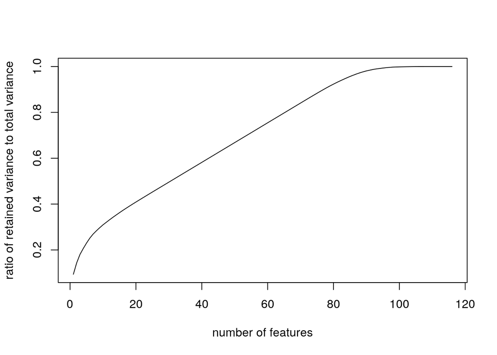

```r
#PCA-visualize training set in 3D
n <- dim(Strn)[1]
a <- Strn[,-ncol(Strn)]
s <- apply(a,2,sd)
constFeatures <- which(s==0)
a <- a[,-c(constFeatures)] # remove features with constant variance
a <- (a-matrix(1,n,1)%*%apply(a,2,mean))/(matrix(1,n,1)%*%apply(a,2,sd)) #normalize
b <- prcomp(a, retx = TRUE)
rv <- cumsum(b$sdev^2) / sum(b$sdev^2)
plot(rv,type="l",xlab="number of features",
     ylab="ratio of retained variance to total variance")
```

```r
X <- as.data.frame(b$x[,1:3])
X$Lb <- Strn$Lb

#if (!require("rgl")) install.packages("rgl")
#library("rgl")
#plot3d(X[,1],X[,2],X[,3],col=X[,4]+1)
```

## Multi-class classification

### Class label statistics (training set)

```r
#Multi-class (Normal,DoS,Probe,R2L,U2R) classification

#class indices (training set)
l <- data_trn[,"attack"]
iNormal <- l =="normal."
iProbe <- l %in% c("satan.","ipsweep.","nmap.",
                   "portsweep.","mscan.","saint.")
iDoS <- l %in% c("back.","land.","neptune.","pod.","smurf.",
                 "teardrop.","apache2.",".udpstorm.","processtable.","mailbomb.")
iU2R <- l %in% c("buffer_overflow.","loadmodule.","rootkit.","perl.","sqlattack.",
                 "xterm.","ps.")
iR2L <- l %in% c("guess_passwd.","ftp_write.","imap.","phf.","multihop.",
                 "warezmaster.","warezclient.","spy.","xlock.","xsnoop.",
                 "snmpguess.","snmpgetattack.","httptunnel.","sendmail.",
                 "named.","worm.")

A <- data_trn[,-43]
labels <- rep(NA,dim(A)[1]) #initialize labels column
labels[iNormal] <- 0
labels[iProbe] <- 1
labels[iDoS] <- 2
labels[iU2R] <- 3
labels[iR2L] <- 4
A$label <- labels

df <- as.data.frame(table(A$label))
colnames(df) <- c("Label", "Frequency")
rownames(df) <- c("Normal", "Probe","DoS","U2R","R2L")
print(df)
```

```
##        Label Frequency
## Normal     0     87832
## Probe      1      2131
## DoS        2     54572
## U2R        3        52
## R2L        4       999
```

### Class label statistics (test set)

```r
#class indices (test set)
l <- data_tst[,"attack"]
iNormal <- l =="normal."
iProbe <- l %in% c("satan.","ipsweep.","nmap.",
                   "portsweep.","mscan.","saint.")
iDoS <- l %in% c("back.","land.","neptune.","pod.","smurf.",
                 "teardrop.","apache2.",".udpstorm.","processtable.","mailbomb.")
iU2R <- l %in% c("buffer_overflow.","loadmodule.","rootkit.","perl.","sqlattack.",
                 "xterm.","ps.")
iR2L <- l %in% c("guess_passwd.","ftp_write.","imap.","phf.","multihop.",
                 "warezmaster.","warezclient.","spy.","xlock.","xsnoop.",
                 "snmpguess.","snmpgetattack.","httptunnel.","sendmail.",
                 "named.","worm.")

B <- data_tst[,-43]
labels <- rep(NA,dim(B)[1]) #initialize labels column
labels[iNormal] <- 0
labels[iProbe] <- 1
labels[iDoS] <- 2
labels[iU2R] <- 3
labels[iR2L] <- 4
B$label <- labels

df <- as.data.frame(table(B$label))
colnames(df) <- c("Label", "Frequency")
rownames(df) <- c("Normal", "Probe","DoS","U2R","R2L")
print(df)
```

```
##        Label Frequency
## Normal     0     47913
## Probe      1      2682
## DoS        2     23566
## U2R        3        70
## R2L        4      3058
```

### One-hot encoding of nominal features

To perform one-hot encoding of features, the training set and test set are first combined since the test set contains additional levels (categories) for some features. Such levels are not apparent in the training set. Once the combined data is encoded, the training set and test test are then split.

```r
#One-hot encoding of nominal features
ta <- A[,-c(42,43)] #remove labels
tb <- B[,-c(42,43)] #remove labels
flg <- dim(ta)[1]
Comb <- rbind(ta,tb)
dmy <- dummyVars(" ~ .", data = Comb)
Comb <- data.frame(predict(dmy, newdata = Comb))
#colnames(Comb)

#Re-split and attach labels
tA <- Comb[1:flg,]
tA$label <- A$label
tB <- Comb[-c(1:flg),]
tB$label <- B$label
```

### Multi-class decision tree

The various classes are re-weighted in proportion to the inverse of their sizes so that smaller classes are not marginalized.

```r
#Classification tree
xtrn <- tA
xtst <- tB

#Weigh against class sizes
w0 <- sum(xtrn$label == 0) / nrow(xtrn)
w1 <- sum(xtrn$label == 1) / nrow(xtrn)
w2 <- sum(xtrn$label == 2) / nrow(xtrn)
w3 <- sum(xtrn$label == 3) / nrow(xtrn)
w4 <- sum(xtrn$label == 4) / nrow(xtrn)

W <- rep(0,nrow(xtrn))
W[(xtrn$label == 0)] <- ceiling(1/w0)
W[(xtrn$label == 1)] <- ceiling(1/w1)
W[(xtrn$label == 2)] <- ceiling(1/w2)
W[(xtrn$label == 3)] <- ceiling(1/w3)
W[(xtrn$label == 4)] <- ceiling(1/w4)

model <- rpart(as.factor(xtrn$label) ~., data=xtrn, weights = W)
predictions <- predict(model, xtst[,-ncol(xtst)], type = "class")
confusionMatrix(predictions, as.factor(xtst[,ncol(xtst)]))
```

```
## Confusion Matrix and Statistics
##
##           Reference
## Prediction     0     1     2     3     4
##          0 47053    45  2543    10   920
##          1   527  2189  2487     7   357
##          2     8   262 18527     1     2
##          3   137   173     0    23   537
##          4   188    13     9    29  1242
##
## Overall Statistics
##
##                Accuracy : 0.8932
##                  95% CI : (0.891, 0.8954)
##     No Information Rate : 0.6199
##     P-Value [Acc > NIR] : < 2.2e-16
##
##                   Kappa : 0.7934
##
##  Mcnemar's Test P-Value : < 2.2e-16
##
## Statistics by Class:
##
##                      Class: 0 Class: 1 Class: 2  Class: 3 Class: 4
## Sensitivity            0.9821  0.81618   0.7862 0.3285714  0.40615
## Specificity            0.8802  0.95472   0.9949 0.9890312  0.99678
## Pos Pred Value         0.9304  0.39321   0.9855 0.0264368  0.83862
## Neg Pred Value         0.9678  0.99313   0.9138 0.9993850  0.97604
## Prevalence             0.6199  0.03470   0.3049 0.0009057  0.03957
## Detection Rate         0.6088  0.02832   0.2397 0.0002976  0.01607
## Detection Prevalence   0.6543  0.07203   0.2432 0.0112565  0.01916
## Balanced Accuracy      0.9311  0.88545   0.8905 0.6588013  0.70146
```